# RQ2: Effectiveness and Efficacy

Sabrina Norwood

11 June, 2026

# Note on Terminology

**Efficacy vs. Effectiveness:** The preregistered analyses (RQ2.1 and RQ2.2) are restricted to completers — participants with activity in both Week 1 and Week 6 — measuring *efficacy* (intervention effects under controlled conditions). The exploratory GLMM models use the full weekly dataset with all participants who had any activity, approximating intention-to-treat and measuring *effectiveness* (real-world intervention effects).

# TODO

- check i understand and have implemented 2.1 and 2.2 correctly

# Dependencies

```r
library(tidyverse)
library(MASS)
library(broom)
library(broom.mixed)
library(emmeans)
library(flextable)
library(officer)
library(AER)
library(lme4)
library(glmmTMB)
library(knitr)
library(kableExtra)

dir.create("../reports/", showWarnings = FALSE)
dir.create("../reports/results_rq2_effectiveness/")
```

# Load data

```r
df_rq2 <- read_csv("../data/processed/data_processed_behavioral_data_open_attempts.csv") %>%
  mutate(condition = relevel(factor(condition), ref = "CCC"))
```

# RQ 2.1: Dismissed app openings in week 6

Model: NB regression, offset = log(attempted_w6). Covariates: dismissed_w1, attempted_w1.

## Assumption check: overdispersion

```r
poisson_21 <- glm(
  dismissed_w6 ~ condition + dismissed_w1 + attempted_w1,
  offset = log(attempted_w6),
  data   = df_rq2,
  family = poisson()
)
disp_test_21 <- dispersiontest(poisson_21)
cat("RQ2.1 dispersion test:", capture.output(print(disp_test_21)), sep = "\n")
```

```
## RQ2.1 dispersion test:
##
##  Overdispersion test
##
## data:  poisson_21
## z = 7.5224, p-value = 2.689e-14
## alternative hypothesis: true dispersion is greater than 1
## sample estimates:
## dispersion
##   5.056697
```

```r
zero_pct_21 <- mean(df_rq2$dismissed_w6 == 0, na.rm = TRUE) * 100
cat(sprintf("RQ2.1 zero proportion: %.1f%%\n", zero_pct_21))
```

```
## RQ2.1 zero proportion: 5.6%
```

## Main model

```r
model_rq2_1 <- glm.nb(
  dismissed_w6 ~ condition + dismissed_w1 + attempted_w1 + offset(log(attempted_w6)),
  data = df_rq2
)

summary(model_rq2_1)
```

```
##
## Call:
## glm.nb(formula = dismissed_w6 ~ condition + dismissed_w1 + attempted_w1 +
##     offset(log(attempted_w6)), data = df_rq2, init.theta = 5.161293531,
##     link = log)
##
## Coefficients:
##                Estimate Std. Error z value Pr(>|z|)
## (Intercept)  -1.5186229  0.0545501 -27.839  < 2e-16 ***
## conditionABC  0.0986744  0.0647197   1.525    0.127
## conditionACC  0.0945023  0.0649834   1.454    0.146
## conditionBCC  0.0033200  0.0667458   0.050    0.960
## dismissed_w1  0.0064145  0.0006723   9.542  < 2e-16 ***
## attempted_w1 -0.0016954  0.0003104  -5.462 4.72e-08 ***
## ---
## Signif. codes:  0 '***' 0.001 '**' 0.01 '*' 0.05 '.' 0.1 ' ' 1
##
## (Dispersion parameter for Negative Binomial(5.1613) family taken to be 1)
##
##     Null deviance: 692.85  on 538  degrees of freedom
## Residual deviance: 580.06  on 533  degrees of freedom
##   (1102 observations deleted due to missingness)
## AIC: 3571.8
##
## Number of Fisher Scoring iterations: 1
##
##
##               Theta:  5.161
##           Std. Err.:  0.453
##
##  2 x log-likelihood:  -3557.756
```

```r
results_rq2_1 <- tidy(model_rq2_1, exponentiate = TRUE, conf.int = TRUE) %>%
  mutate(
    RR   = round(estimate, 3),
    CI   = paste0("[", round(conf.low, 3), ", ", round(conf.high, 3), "]"),
    p    = case_when(p.value < .001 ~ "< .001",
                     TRUE           ~ as.character(round(p.value, 3)))
  ) %>%
  dplyr::select(Predictor = term, `Rate Ratio` = RR, `95% CI` = CI, p)

results_rq2_1 |> kable() |> kable_classic()
```

| Predictor | Rate Ratio | 95% CI | p |
| --- | --- | --- | --- |
| (Intercept) | 0.219 | [0.197, 0.244] | < .001 |
| conditionABC | 1.104 | [0.972, 1.253] | 0.127 |
| conditionACC | 1.099 | [0.968, 1.248] | 0.146 |
| conditionBCC | 1.003 | [0.88, 1.144] | 0.96 |
| dismissed_w1 | 1.006 | [1.005, 1.008] | < .001 |
| attempted_w1 | 0.998 | [0.998, 0.999] | < .001 |

```r
write_csv(results_rq2_1, "../reports/results_rq2_effectiveness/model_rq2_1_results.csv")
```

## Pairwise comparisons

```r
pairwise_rq2_1 <- emmeans(model_rq2_1, ~ condition) %>%
  contrast("pairwise", adjust = "none") %>%
  summary(infer = TRUE, type = "response") %>%
  as_tibble() %>%
  mutate(
    across(where(is.numeric), ~ round(.x, 3)),
    p = case_when(p.value < .001 ~ "< .001",
                  TRUE           ~ as.character(round(p.value, 3)))
  )

pairwise_rq2_1 |> kable() |> kable_classic()
```

| contrast | ratio | SE | df | asymp.LCL | asymp.UCL | null | z.ratio | p.value | p |
| --- | --- | --- | --- | --- | --- | --- | --- | --- | --- |
| CCC / ABC | 0.906 | 0.059 | Inf | 0.798 | 1.029 | 1 | -1.525 | 0.127 | 0.127 |
| CCC / ACC | 0.910 | 0.059 | Inf | 0.801 | 1.033 | 1 | -1.454 | 0.146 | 0.146 |
| CCC / BCC | 0.997 | 0.067 | Inf | 0.874 | 1.136 | 1 | -0.050 | 0.960 | 0.96 |
| ABC / ACC | 1.004 | 0.065 | Inf | 0.885 | 1.139 | 1 | 0.065 | 0.948 | 0.948 |
| ABC / BCC | 1.100 | 0.073 | Inf | 0.965 | 1.254 | 1 | 1.429 | 0.153 | 0.153 |
| ACC / BCC | 1.095 | 0.074 | Inf | 0.960 | 1.250 | 1 | 1.357 | 0.175 | 0.175 |

```r
write_csv(pairwise_rq2_1, "../reports/results_rq2_effectiveness/pairwise_rq2_1.csv")
```

## Estimated marginal means: predicted dismissal rate per condition

```r
condition_order <- c("ABC", "ACC", "BCC", "CCC")

em_pred_rq2_1 <- emmeans(model_rq2_1, ~ condition, type = "response") |>
  summary(infer = TRUE) |>
  as_tibble() |>
  mutate(condition = factor(condition, levels = condition_order)) |>
  arrange(condition)

em_pred_rq2_1_table <- em_pred_rq2_1 |>
  mutate(
    `95% CI` = paste0("[", signif(asymp.LCL, 3), ", ", signif(asymp.UCL, 3), "]"),
    across(where(is.numeric), ~ round(.x, 3))
  ) |>
  dplyr::select(Condition = condition, `Dismissals per attempt` = response, SE, `95% CI`)

em_pred_rq2_1_table |> kable() |> kable_classic()
```

| Condition | Dismissals per attempt | SE | 95% CI |
| --- | --- | --- | --- |
| ABC | 22.363 | 1.018 | [20.5, 24.5] |
| ACC | 22.270 | 1.028 | [20.3, 24.4] |
| BCC | 20.329 | 0.997 | [18.5, 22.4] |
| CCC | 20.262 | 0.927 | [18.5, 22.2] |

```r
write_csv(em_pred_rq2_1_table, "../reports/results_rq2_effectiveness/emmeans_rq2_1.csv")
```

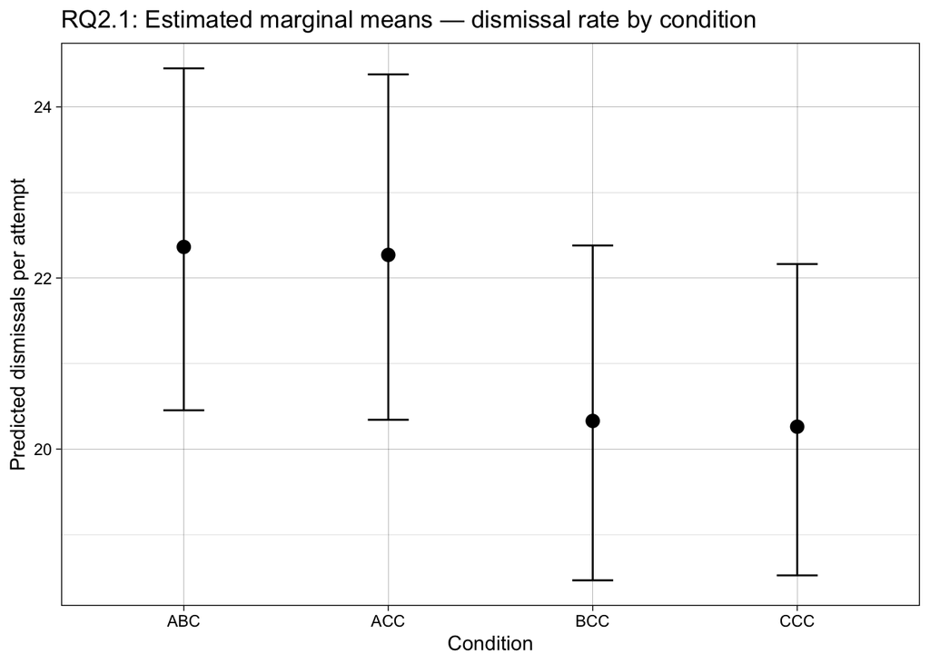

```r
p_em_rq2_1 <- ggplot(em_pred_rq2_1,
                     aes(x = condition, y = response, ymin = asymp.LCL, ymax = asymp.UCL)) +
  geom_point(size = 3) +
  geom_errorbar(width = 0.2) +
  labs(x = "Condition", y = "Predicted dismissals per attempt",
       title = "RQ2.1: Estimated marginal means — dismissal rate by condition") +
  theme_linedraw()

p_em_rq2_1
```

```r
ggsave("../reports/results_rq2_effectiveness/emmeans_rq2_1_plot.png",
       p_em_rq2_1, width = 5, height = 4, dpi = 150)
```

## Relative reduction: % dismissed of attempted per condition × week

```r
# TODO
```

# RQ 2.2: Initial app opening attempts in week 6

Model: NB regression, covariate = attempted_w1.

## Assumption check: overdispersion

```r
poisson_22 <- glm(
  attempted_w6 ~ condition + attempted_w1,
  data   = df_rq2,
  family = poisson()
)
disp_test_22 <- dispersiontest(poisson_22)
cat("\nRQ2.2 dispersion test:", capture.output(print(disp_test_22)), sep = "\n")
```

```
##
## RQ2.2 dispersion test:
##
##  Overdispersion test
##
## data:  poisson_22
## z = 11.107, p-value < 2.2e-16
## alternative hypothesis: true dispersion is greater than 1
## sample estimates:
## dispersion
##   36.99825
```

```r
zero_pct_22 <- mean(df_rq2$attempted_w6 == 0, na.rm = TRUE) * 100
cat(sprintf("RQ2.2 zero proportion: %.1f%%\n", zero_pct_22))
```

```
## RQ2.2 zero proportion: 0.0%
```

## Main model

```r
model_rq2_2 <- glm.nb(
  attempted_w6 ~ condition + attempted_w1,
  data = df_rq2
)

summary(model_rq2_2)
```

```
##
## Call:
## glm.nb(formula = attempted_w6 ~ condition + attempted_w1, data = df_rq2,
##     init.theta = 1.851311173, link = log)
##
## Coefficients:
##                Estimate Std. Error z value Pr(>|z|)
## (Intercept)   3.4978629  0.0743724  47.032   <2e-16 ***
## conditionABC  0.0195148  0.0897490   0.217   0.8279
## conditionACC -0.1864296  0.0889691  -2.095   0.0361 *
## conditionBCC  0.0186128  0.0926300   0.201   0.8407
## attempted_w1  0.0052366  0.0002554  20.504   <2e-16 ***
## ---
## Signif. codes:  0 '***' 0.001 '**' 0.01 '*' 0.05 '.' 0.1 ' ' 1
##
## (Dispersion parameter for Negative Binomial(1.8513) family taken to be 1)
##
##     Null deviance: 995.47  on 538  degrees of freedom
## Residual deviance: 591.68  on 534  degrees of freedom
##   (1102 observations deleted due to missingness)
## AIC: 5579.1
##
## Number of Fisher Scoring iterations: 1
##
##
##               Theta:  1.851
##           Std. Err.:  0.111
##
##  2 x log-likelihood:  -5567.104
```

```r
results_rq2_2 <- tidy(model_rq2_2, exponentiate = TRUE, conf.int = TRUE) %>%
  mutate(
    RR   = round(estimate, 3),
    CI   = paste0("[", round(conf.low, 3), ", ", round(conf.high, 3), "]"),
    p    = case_when(p.value < .001 ~ "< .001",
                     TRUE           ~ as.character(round(p.value, 3)))
  ) %>%
  dplyr::select(Predictor = term, `Rate Ratio` = RR, `95% CI` = CI, p)

results_rq2_2 |> kable() |> kable_classic()
```

| Predictor | Rate Ratio | 95% CI | p |
| --- | --- | --- | --- |
| (Intercept) | 33.045 | [28.406, 38.57] | < .001 |
| conditionABC | 1.020 | [0.855, 1.216] | 0.828 |
| conditionACC | 0.830 | [0.697, 0.988] | 0.036 |
| conditionBCC | 1.019 | [0.85, 1.222] | 0.841 |
| attempted_w1 | 1.005 | [1.005, 1.006] | < .001 |

```r
write_csv(results_rq2_2, "../reports/results_rq2_effectiveness/model_rq2_2_results.csv")
```

## Pairwise comparisons

```r
pairwise_rq2_2 <- emmeans(model_rq2_2, ~ condition) %>%
  contrast("pairwise", adjust = "none") %>%
  summary(infer = TRUE, type = "response") %>%
  as_tibble() %>%
  mutate(
    across(where(is.numeric), ~ round(.x, 3)),
    p = case_when(p.value < .001 ~ "< .001",
                  TRUE           ~ as.character(round(p.value, 3)))
  )

pairwise_rq2_2 |> kable() |> kable_classic()
```

| contrast | ratio | SE | df | asymp.LCL | asymp.UCL | null | z.ratio | p.value | p |
| --- | --- | --- | --- | --- | --- | --- | --- | --- | --- |
| CCC / ABC | 0.981 | 0.088 | Inf | 0.822 | 1.169 | 1 | -0.217 | 0.828 | 0.828 |
| CCC / ACC | 1.205 | 0.107 | Inf | 1.012 | 1.434 | 1 | 2.095 | 0.036 | 0.036 |
| CCC / BCC | 0.982 | 0.091 | Inf | 0.819 | 1.177 | 1 | -0.201 | 0.841 | 0.841 |
| ABC / ACC | 1.229 | 0.110 | Inf | 1.031 | 1.465 | 1 | 2.298 | 0.022 | 0.022 |
| ABC / BCC | 1.001 | 0.093 | Inf | 0.834 | 1.202 | 1 | 0.010 | 0.992 | 0.992 |
| ACC / BCC | 0.815 | 0.075 | Inf | 0.680 | 0.976 | 1 | -2.218 | 0.027 | 0.027 |

```r
write_csv(pairwise_rq2_2, "../reports/results_rq2_effectiveness/pairwise_rq2_2.csv")
```

## Estimated marginal means: predicted attempt count per condition

```r
em_pred_rq2_2 <- emmeans(model_rq2_2, ~ condition, type = "response") |>
  summary(infer = TRUE) |>
  as_tibble() |>
  mutate(condition = factor(condition, levels = condition_order)) |>
  arrange(condition)

em_pred_rq2_2_table <- em_pred_rq2_2 |>
  mutate(
    `95% CI` = paste0("[", signif(asymp.LCL, 3), ", ", signif(asymp.UCL, 3), "]"),
    across(where(is.numeric), ~ round(.x, 3))
  ) |>
  dplyr::select(Condition = condition, `Mean attempts` = response, SE, `95% CI`)

em_pred_rq2_2_table |> kable() |> kable_classic()
```

| Condition | Mean attempts | SE | 95% CI |
| --- | --- | --- | --- |
| ABC | 73.858 | 4.722 | [65.2, 83.7] |
| ACC | 60.111 | 3.774 | [53.2, 68] |
| BCC | 73.791 | 5.006 | [64.6, 84.3] |
| CCC | 72.431 | 4.565 | [64, 82] |

```r
write_csv(em_pred_rq2_2_table, "../reports/results_rq2_effectiveness/emmeans_rq2_2.csv")
```

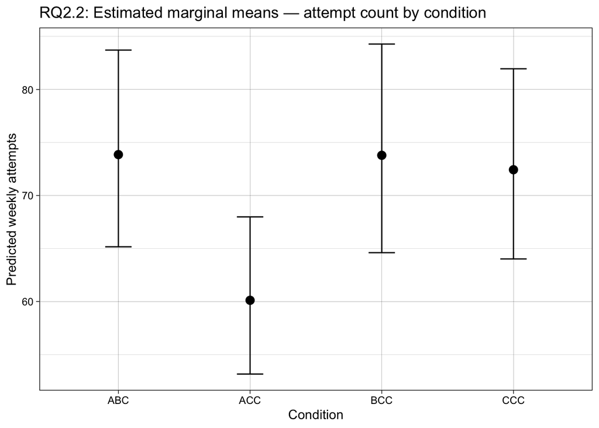

```r
p_em_rq2_2 <- ggplot(em_pred_rq2_2,
                     aes(x = condition, y = response, ymin = asymp.LCL, ymax = asymp.UCL)) +
  geom_point(size = 3) +
  geom_errorbar(width = 0.2) +
  labs(x = "Condition", y = "Predicted weekly attempts",
       title = "RQ2.2: Estimated marginal means — attempt count by condition") +
  theme_linedraw()

p_em_rq2_2
```

```r
ggsave("../reports/results_rq2_effectiveness/emmeans_rq2_2_plot.png",
       p_em_rq2_2, width = 5, height = 4, dpi = 150)
```

## Mean initial attempts per user per condition × week

```r
# TODO
#
# df_weekly_attempts <- df_rq2_event %>%
#   group_by(participant_id, condition, study_week) %>%
#   summarise(initial = sum(initial_attempt), .groups = "drop") %>%
#   group_by(condition, study_week) %>%
#   summarise(
#     n_users      = n(),
#     mean_initial = round(mean(initial), 2),
#     .groups = "drop"
#   )
#
# df_weekly_attempts
#
# write_csv(df_weekly_attempts, "../reports/results_rq2_effectiveness/weekly_attempts_by_condition.csv")
#
# # Reduction from week 1 to week 6
# df_reduction_w1w6 <- df_weekly_attempts %>%
#   filter(study_week %in% c(1, 6)) %>%
#   pivot_wider(names_from = study_week, values_from = c(mean_initial, n_users),
#               names_glue = "{.value}_w{study_week}") %>%
#   mutate(
#     absolute_reduction = round(mean_attempted_w1 - mean_attempted_w6, 2),
#     relative_reduction = round((mean_attempted_w1 - mean_attempted_w6) / mean_attempted_w1 * 100, 1)
#   )
#
# print(df_reduction_w1w6)
# write_csv(df_reduction_w1w6, "../reports/results_rq2_effectiveness/reduction_w1_to_w6.csv")
```

# Word tables

```r
doc <- read_docx() %>%
  body_add_par("RQ2.1: NB Regression — Dismissed Openings (Week 6)", style = "heading 1") %>%
  body_add_flextable(flextable(results_rq2_1) %>% autofit()) %>%
  body_add_par("", style = "Normal") %>%
  body_add_par("Estimated Marginal Means (predicted dismissal rate)", style = "heading 2") %>%
  body_add_flextable(flextable(em_pred_rq2_1_table) %>% autofit()) %>%
  body_add_par("", style = "Normal") %>%
  body_add_par("Pairwise Comparisons", style = "heading 2") %>%
  body_add_flextable(flextable(pairwise_rq2_1 %>%
                                 dplyr::select(contrast, ratio, SE, asymp.LCL, asymp.UCL, p)) %>%
                       autofit()) %>%
  body_add_par("", style = "Normal") %>%
  body_add_par("RQ2.2: NB Regression — Initial App Opening Attempts (Week 6)", style = "heading 1") %>%
  body_add_flextable(flextable(results_rq2_2) %>% autofit()) %>%
  body_add_par("", style = "Normal") %>%
  body_add_par("Estimated Marginal Means (predicted attempt count)", style = "heading 2") %>%
  body_add_flextable(flextable(em_pred_rq2_2_table) %>% autofit()) %>%
  body_add_par("", style = "Normal") %>%
  body_add_par("Pairwise Comparisons", style = "heading 2") %>%
  body_add_flextable(flextable(pairwise_rq2_2 %>%
                                 dplyr::select(contrast, ratio, SE, asymp.LCL, asymp.UCL, p)) %>%
                       autofit())

print(doc, target = "../reports/results_rq2_effectiveness/results_rq2.docx")
```

# Non preregistered model: longitudinal binomial / NB GLMM

**Research question shift.** The preregistered RQ2.1 and RQ2.2 ask whether *condition assignment* affects week-6 outcomes — intention-to-treat (ITT) questions about the randomised arm. The non-preregistered models below reframe these to **dose-response** questions: does the *current delay length* (in seconds) affect the dismissal rate / weekly attempt count, with the trajectory unfolding over all 6 weeks? This is a different scientific question — does the delay dose itself drive behaviour, regardless of which condition produced it — and complements rather than replaces the preregistered ITT analysis above.

**Why move away from the week-6-only spec.** Three problems with the preregistered week-6 cross-sectional models:

1. **Selection / collider bias.** Condition affects who reaches week 6 (RQ1 is precisely about this). Restricting RQ2 to completers makes the week-6 cohort non-comparable across conditions, biasing the condition effect in an unknown direction. No covariate adjustment in the week-6 model fixes this — the bias is baked into the design choice to analyze week 6 alone.
2. **Post-treatment offset (RQ2.1).** `attempted_w6` is itself an outcome influenced by condition (it is the outcome of RQ2.2). Using it as an offset conditions on a downstream variable. The rate ratio for `condition` then has a slippery interpretation: “dismissals per attempt, holding attempts fixed at whatever they happened to be in this condition.”
3. **Wasted information.** Weeks 2–5 are discarded entirely.

**Why a GLMM on weekly counts.** The model uses all 6 weeks, with a random intercept per participant to share strength without conditioning on completion. Participants who drop out simply contribute fewer rows; under MAR-style dropout assumptions, the estimator does not need a completers-only restriction. The binomial spec is the natural one for “successes/trials” — no offset needed.

**Why `delay_secs` instead of `condition`.** Using the time-varying current delay length (3s/6s/10s) operationalises the dose-response question directly. This is more sensitive than a 3-df condition contrast for two reasons: it uses 1 df, and because ABC/ACC/BCC participants experience multiple delays over the study, every such participant partially serves as their own control. The within-subject identification here is much stronger than in RQ1’s hazard model — within-subject contrasts (e.g. an ABC participant at 3s in week 1 vs the same participant at 10s in week 5) directly identify the dose effect.

```r
# Weekly file: one row per participant × at-risk week (1..last_week).
# Weeks where the participant was active but had no events of the relevant
# type are explicit zeros; weeks past last_week are absent (post-dropout).
weekly <- read_csv("../data/processed/data_processed_behavioral_data_weekly.csv",
                   show_col_types = FALSE) %>%
  mutate(condition = relevel(factor(condition), ref = "CCC"))

cat("Person-weeks:", nrow(weekly),
    "\nUnique participants:", n_distinct(weekly$participant_id), "\n")
```

```
## Person-weeks: 5669
## Unique participants: 1641
```

## RQ2.1 analogue: dismissal rate trajectory

Binomial spec models the proportion of attempts dismissed. Weeks with `attempted == 0` carry no information about the dismissal *rate* and are excluded — they would force `0/0` cells.

```r
# Centre predictors so the main-effect coefficients are interpretable at
# the mean of the other predictor (otherwise the `delay_secs` main effect
# would be the slope at study_week = 0, which is outside the data). Matches
# the parameterisation used by m_attempts below.
delay_mean <- mean(weekly$delay_secs)
week_mean  <- mean(weekly$study_week)

weekly_dismiss_c <- weekly |>
  filter(attempted > 0) |>
  mutate(
    delay_secs_c = delay_secs - delay_mean,
    study_week_c = study_week - week_mean
  )

m_dismiss <- glmer(
  cbind(dismissed, attempted - dismissed) ~ delay_secs_c * study_week_c + (1 | participant_id),
  family  = binomial,
  data    = weekly_dismiss_c,
  control = glmerControl(optimizer = "bobyqa")
)
summary(m_dismiss)
```

```
## Generalized linear mixed model fit by maximum likelihood (Laplace
##   Approximation) [glmerMod]
##  Family: binomial  ( logit )
## Formula:
## cbind(dismissed, attempted - dismissed) ~ delay_secs_c * study_week_c +
##     (1 | participant_id)
##    Data: weekly_dismiss_c
## Control: glmerControl(optimizer = "bobyqa")
##
##       AIC       BIC    logLik -2*log(L)  df.resid
##   42568.3   42601.5  -21279.1   42558.3      5626
##
## Scaled residuals:
##      Min       1Q   Median       3Q      Max
## -12.7296  -0.9303  -0.1365   0.8909  12.2063
##
## Random effects:
##  Groups         Name        Variance Std.Dev.
##  participant_id (Intercept) 0.6195   0.7871
## Number of obs: 5631, groups:  participant_id, 1641
##
## Fixed effects:
##                            Estimate Std. Error z value Pr(>|z|)
## (Intercept)               -1.164839   0.022679  -51.36   <2e-16 ***
## delay_secs_c               0.111130   0.002518   44.13   <2e-16 ***
## study_week_c              -0.189672   0.003746  -50.64   <2e-16 ***
## delay_secs_c:study_week_c  0.034348   0.001249   27.51   <2e-16 ***
## ---
## Signif. codes:  0 '***' 0.001 '**' 0.01 '*' 0.05 '.' 0.1 ' ' 1
##
## Correlation of Fixed Effects:
##             (Intr) dly_s_ stdy__
## delay_scs_c -0.108
## study_wek_c  0.143 -0.818
## dly_scs_:__ -0.189  0.587 -0.585
## optimizer (bobyqa) convergence code: 0 (OK)
## Model is nearly unidentifiable: very large eigenvalue
##  - Rescale variables?
```

```r
# Fixed-effect coefficient table. Binomial GLMM → exponentiated coefficients
# are odds ratios. With centring:
#   delay_secs_c              = per-second dose effect at mean week
#   study_week_c              = time trend at mean delay
#   delay_secs_c:study_week_c = interaction (unchanged by centring)
results_glmm_dismiss <- broom.mixed::tidy(m_dismiss,
                                          effects       = "fixed",
                                          exponentiate  = TRUE,
                                          conf.int      = TRUE) %>%
  mutate(
    OR = round(estimate, 3),
    CI = paste0("[", round(conf.low, 3), ", ", round(conf.high, 3), "]"),
    p  = case_when(p.value < .001 ~ "< .001",
                   TRUE           ~ as.character(round(p.value, 3)))
  ) %>%
  dplyr::select(Predictor = term, OR, `95% CI` = CI, p)

results_glmm_dismiss |> kable() |> kable_classic()
```

| Predictor | OR | 95% CI | p |
| --- | --- | --- | --- |
| (Intercept) | 0.312 | [0.298, 0.326] | < .001 |
| delay_secs_c | 1.118 | [1.112, 1.123] | < .001 |
| study_week_c | 0.827 | [0.821, 0.833] | < .001 |
| delay_secs_c:study_week_c | 1.035 | [1.032, 1.037] | < .001 |

```r
write_csv(results_glmm_dismiss,
          "../reports/results_rq2_effectiveness/glmm_dismiss_results.csv")
write_rds(m_dismiss,
          "../reports/results_rq2_effectiveness/glmm_dismiss.rds")

# Dose slope by week (emtrends), reported on the original week scale.
# emtrends is evaluated at centred week values corresponding to weeks 1, 3,
# 6 on the original scale; the displayed `Study week` column adds the mean
# back so the table is interpretable.
em_slopes_dismiss <- emtrends(
  m_dismiss, ~ study_week_c,
  var = "delay_secs_c",
  at  = list(study_week_c = c(1, 3, 6) - week_mean)
) |>
  summary(infer = TRUE) |>
  as_tibble() |>
  mutate(
    `Study week` = study_week_c + week_mean,
    OR_per_sec   = signif(exp(delay_secs_c.trend), 3),
    CI           = paste0("[", signif(exp(asymp.LCL), 3), ", ",
                                signif(exp(asymp.UCL), 3), "]"),
    p            = case_when(p.value < .001 ~ "< .001",
                             TRUE           ~ as.character(round(p.value, 3)))
  ) |>
  dplyr::select(`Study week`,
                `OR per sec of delay` = OR_per_sec,
                `95% CI`              = CI,
                p)

em_slopes_dismiss |> kable() |> kable_classic()
```

| Study week | OR per sec of delay | 95% CI | p |
| --- | --- | --- | --- |
| 1 | 1.05 | [1.04, 1.05] | < .001 |
| 3 | 1.12 | [1.12, 1.13] | < .001 |
| 6 | 1.24 | [1.23, 1.26] | < .001 |

```r
write_csv(em_slopes_dismiss,
          "../reports/results_rq2_effectiveness/glmm_dismiss_slopes.csv")

# Predicted dismissal probability at specific (delay, week) combinations.
# Model uses centred predictors, so convert original-scale grid points to
# the centred scale before passing to emmeans, then convert back for display.
em_pred_dismiss <- emmeans(
  m_dismiss, ~ delay_secs_c * study_week_c,
  at   = list(
    delay_secs_c = c(3, 6, 10) - delay_mean,
    study_week_c = c(1, 3, 6) - week_mean
  ),
  type = "response"
) |>
  summary(infer = TRUE) |>
  as_tibble() |>
  mutate(
    `Delay (s)`   = delay_secs_c + delay_mean,
    `Study week`  = study_week_c + week_mean,
    `Pr(dismiss)` = signif(prob, 3),
    `95% CI`      = paste0("[", signif(asymp.LCL, 3), ", ",
                                signif(asymp.UCL, 3), "]")
  ) |>
  dplyr::select(`Delay (s)`, `Study week`, `Pr(dismiss)`, `95% CI`)

em_pred_dismiss |> kable() |> kable_classic()
```

| Delay (s) | Study week | Pr(dismiss) | 95% CI |
| --- | --- | --- | --- |
| 3 | 1 | 0.2660 | [0.257, 0.275] |
| 6 | 1 | 0.2940 | [0.285, 0.303] |
| 10 | 1 | 0.3330 | [0.323, 0.344] |
| 3 | 3 | 0.1530 | [0.147, 0.16] |
| 6 | 3 | 0.2040 | [0.196, 0.211] |
| 10 | 3 | 0.2880 | [0.279, 0.297] |
| 3 | 6 | 0.0603 | [0.0554, 0.0656] |
| 6 | 6 | 0.1100 | [0.104, 0.116] |
| 10 | 6 | 0.2280 | [0.22, 0.236] |

```r
write_csv(em_pred_dismiss,
          "../reports/results_rq2_effectiveness/glmm_dismiss_predicted.csv")

# Full grid of predictions on original scale (needed to filter to observed cells below).
plot_data_dismiss <- emmeans(
  m_dismiss, ~ delay_secs_c * study_week_c,
  at   = list(
    delay_secs_c = c(3, 6, 10) - delay_mean,
    study_week_c = (1:6) - week_mean
  ),
  type = "response"
) |>
  summary() |>
  as_tibble() |>
  mutate(
    `Delay (s)` = factor(delay_secs_c + delay_mean),
    delay_secs  = delay_secs_c + delay_mean,
    study_week  = study_week_c + week_mean
  )

# Companion: condition-level trajectory.
# The dose-response model above evaluates the linear (delay × week) surface
# at combinations that don't all occur in the data (e.g., 3s at week 6,
# which no condition reaches). The condition-level model below replaces
# `delay_secs` with `condition`, so each predicted line corresponds to one
# of the four randomised arms — the predictions stay inside the design,
# no extrapolation beyond observed (delay × week) cells.
m_dismiss_cond <- glmmTMB(
  cbind(dismissed, attempted - dismissed) ~ condition * study_week + (1 | participant_id),
  family = binomial,
  data   = filter(weekly, attempted > 0)
)
summary(m_dismiss_cond)
```

```
##  Family: binomial  ( logit )
## Formula:
## cbind(dismissed, attempted - dismissed) ~ condition * study_week +
##     (1 | participant_id)
## Data: filter(weekly, attempted > 0)
##
##       AIC       BIC    logLik -2*log(L)  df.resid
##   43986.0   44045.8  -21984.0   43968.0      5622
##
## Random effects:
##
## Conditional model:
##  Groups         Name        Variance Std.Dev.
##  participant_id (Intercept) 0.626    0.7912
## Number of obs: 5631, groups:  participant_id, 1641
##
## Conditional model:
##                          Estimate Std. Error z value Pr(>|z|)
## (Intercept)             -0.506377   0.045940 -11.023  < 2e-16 ***
## conditionABC            -0.606388   0.065210  -9.299  < 2e-16 ***
## conditionACC            -0.578780   0.064111  -9.028  < 2e-16 ***
## conditionBCC            -0.392924   0.064811  -6.063 1.34e-09 ***
## study_week              -0.125018   0.004057 -30.814  < 2e-16 ***
## conditionABC:study_week  0.109208   0.005809  18.801  < 2e-16 ***
## conditionACC:study_week  0.121388   0.005966  20.345  < 2e-16 ***
## conditionBCC:study_week  0.062904   0.005930  10.608  < 2e-16 ***
## ---
## Signif. codes:  0 '***' 0.001 '**' 0.01 '*' 0.05 '.' 0.1 ' ' 1
```

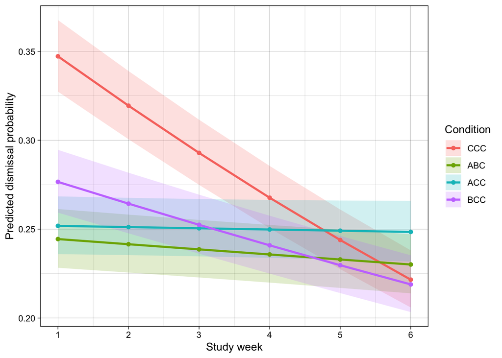

```r
plot_data_dismiss_cond <- emmeans(
  m_dismiss_cond, ~ condition * study_week,
  at   = list(study_week = 1:6),
  type = "response"
) |>
  summary(infer = TRUE) |>
  as_tibble() |>
  rename_with(~ "ci_lower", any_of(c("asymp.LCL", "lower.CL"))) |>
  rename_with(~ "ci_upper", any_of(c("asymp.UCL", "upper.CL")))

p_dismiss_cond <- ggplot(plot_data_dismiss_cond,
                         aes(study_week, prob,
                             colour = condition, fill = condition,
                             group  = condition)) +
  geom_ribbon(aes(ymin = ci_lower, ymax = ci_upper),
              alpha = 0.2, colour = NA) +
  geom_line(linewidth = 1) +
  geom_point() +
  scale_x_continuous(breaks = 1:6) +
  labs(x = "Study week", y = "Predicted dismissal probability",
       colour = "Condition", fill = "Condition") +
  theme_linedraw()

p_dismiss_cond
```

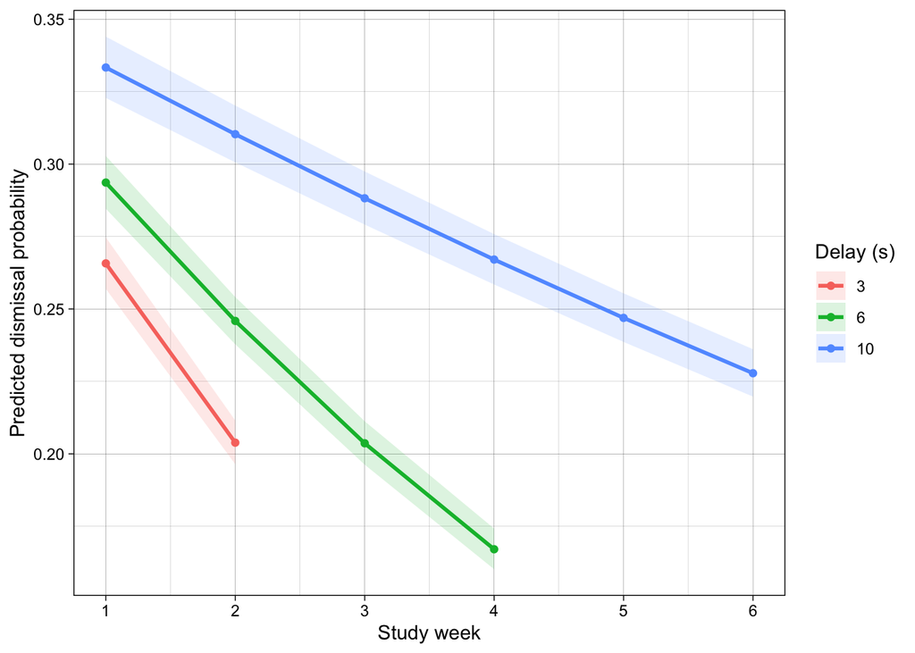

```r
ggsave("../reports/results_rq2_effectiveness/glmm_dismiss_trajectory_by_condition.png",
       p_dismiss_cond, width = 6, height = 4, dpi = 150)

# Dose-response trajectory restricted to observed (delay × week) cells.
# 3s shown for weeks 1–2 only; 6s for weeks 1–4; 10s for all 6 weeks.
observed_cells <- weekly |> distinct(delay_secs, study_week)

plot_data_dismiss_obs <- plot_data_dismiss |>
  semi_join(observed_cells, by = c("delay_secs", "study_week"))

p_dismiss_obs <- ggplot(plot_data_dismiss_obs,
                        aes(study_week, prob,
                            colour = `Delay (s)`, fill = `Delay (s)`,
                            group  = `Delay (s)`)) +
  geom_ribbon(aes(ymin = asymp.LCL, ymax = asymp.UCL),
              alpha = 0.15, colour = NA) +
  geom_line(linewidth = 1) +
  geom_point() +
  scale_x_continuous(breaks = 1:6) +
  labs(x = "Study week", y = "Predicted dismissal probability",
       colour = "Delay (s)", fill = "Delay (s)") +
  theme_linedraw()

p_dismiss_obs
```

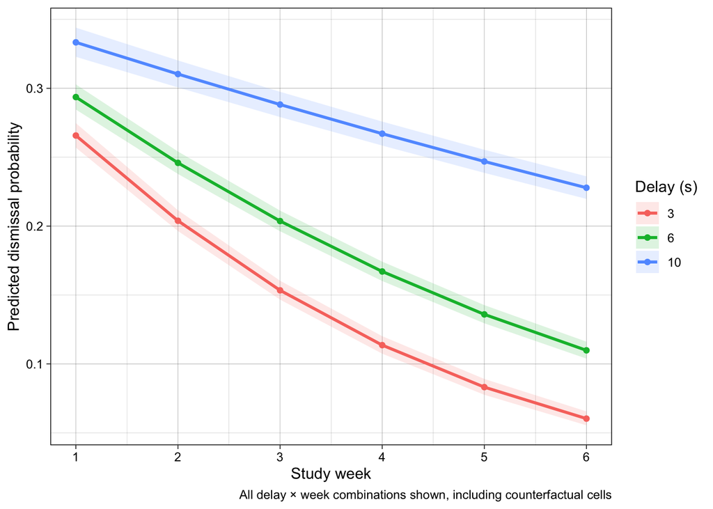

```r
ggsave("../reports/results_rq2_effectiveness/glmm_dismiss_trajectory_observed.png",
       p_dismiss_obs, width = 6, height = 4, dpi = 150)

# Full-grid dose-response trajectory: all delay × week combinations including
# those that never occurred in the study (e.g. 3s at week 6). Extrapolation
# beyond the design, so interpret with caution — but shows the model's full
# implied surface.
p_dismiss_full <- ggplot(plot_data_dismiss,
                         aes(study_week, prob,
                             colour = `Delay (s)`, fill = `Delay (s)`,
                             group  = `Delay (s)`)) +
  geom_ribbon(aes(ymin = asymp.LCL, ymax = asymp.UCL),
              alpha = 0.15, colour = NA) +
  geom_line(linewidth = 1) +
  geom_point() +
  scale_x_continuous(breaks = 1:6) +
  labs(x = "Study week", y = "Predicted dismissal probability",
       colour = "Delay (s)", fill = "Delay (s)",
       caption = "All delay × week combinations shown, including counterfactual cells") +
  theme_linedraw()

p_dismiss_full
```

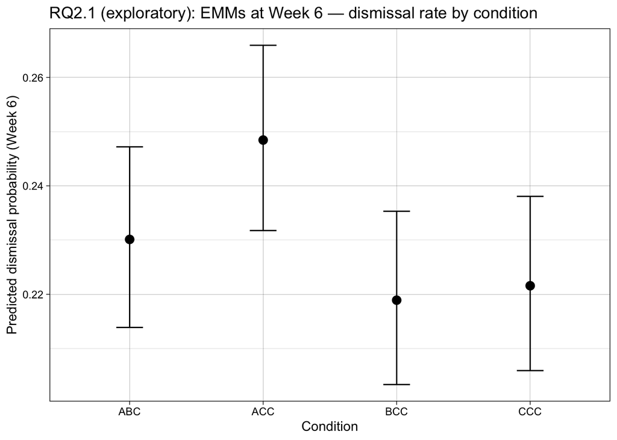

```r
ggsave("../reports/results_rq2_effectiveness/glmm_dismiss_trajectory_full.png",
       p_dismiss_full, width = 6, height = 4, dpi = 150)

# EMMs at Week 6 only — same format as preregistered EMM plot.
condition_order <- c("ABC", "ACC", "BCC", "CCC")

em_dismiss_w6 <- plot_data_dismiss_cond |>
  filter(study_week == 6) |>
  mutate(condition = factor(condition, levels = condition_order)) |>
  arrange(condition)

p_dismiss_w6 <- ggplot(em_dismiss_w6,
                       aes(x = condition, y = prob,
                           ymin = ci_lower, ymax = ci_upper)) +
  geom_point(size = 3) +
  geom_errorbar(width = 0.2) +
  labs(x = "Condition", y = "Predicted dismissal probability (Week 6)",
       title = "RQ2.1 (exploratory): EMMs at Week 6 — dismissal rate by condition") +
  theme_linedraw()

p_dismiss_w6
```

```r
ggsave("../reports/results_rq2_effectiveness/glmm_dismiss_emm_w6.png",
       p_dismiss_w6, width = 5, height = 4, dpi = 150)
```

- Hypothesis test provided by the delay_secs parameter.